# Project #4 - Bank Customers Churn Prediction

#### Correlation check

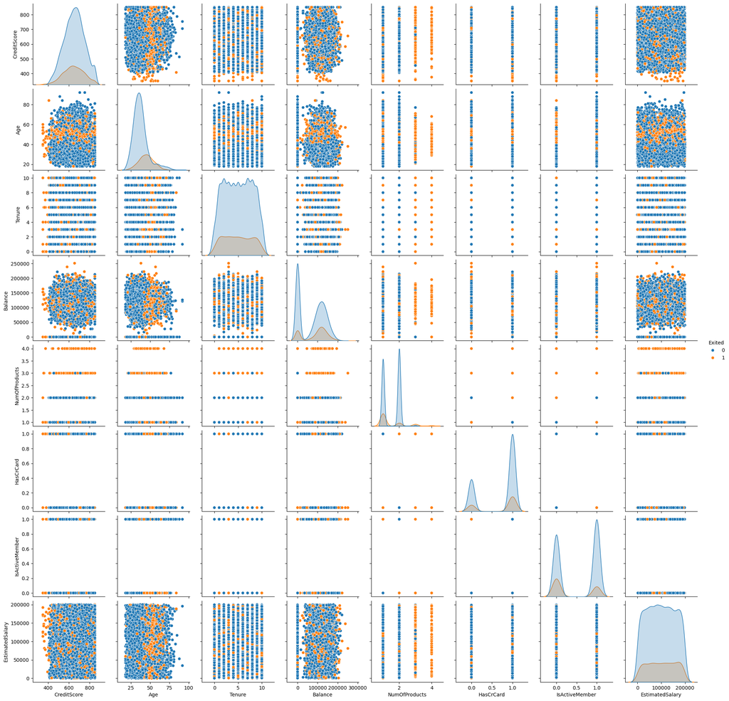

```python
sns.pairplot(data, diag_kind="kde", hue="Exited")
plt.show()
```

- Overall, both **Age** and **NumOfProducts** seem to show strong correlations with churn and could be important features in the classification model.

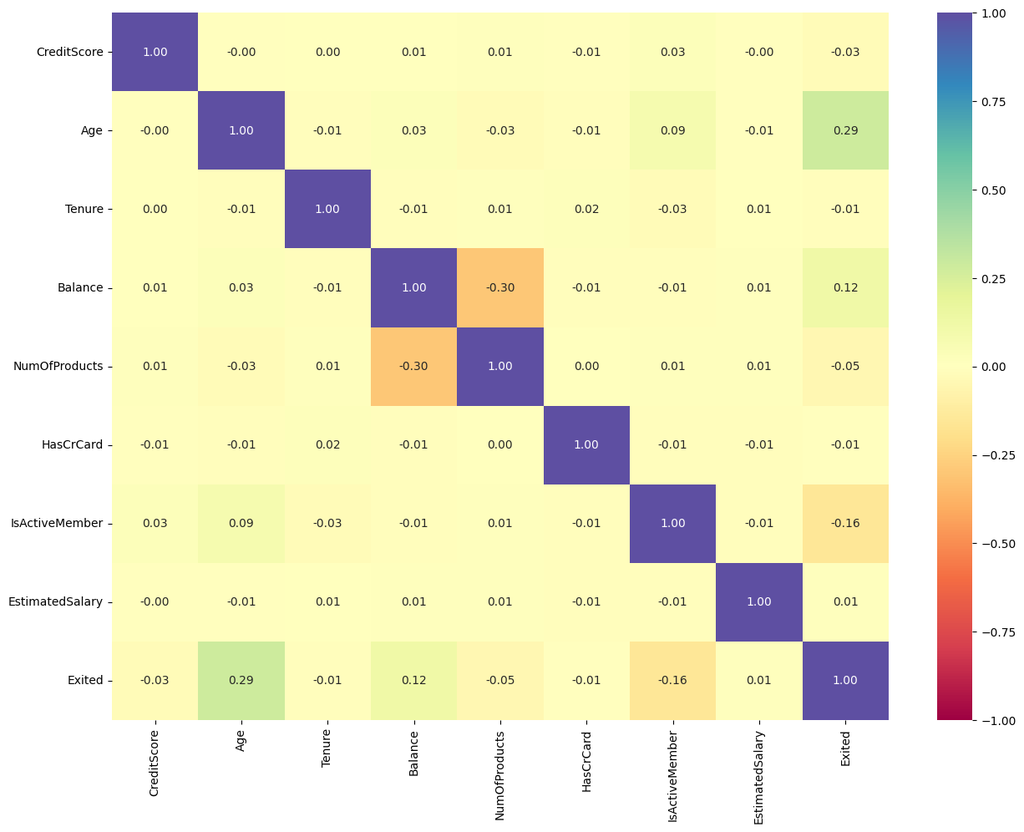

```python
plt.figure(figsize=(15,11))
sns.heatmap(data.corr(numeric_only=True), annot=True, vmin=-1, vmax=1, fmt='.2f', cmap="Spectral")   # Linear correlation
#sns.heatmap(data.corr(numeric_only=True, method="spearman"), annot=True, vmin=-1, vmax=1, fmt=".2f", cmap="Spectral")   # Non-linear correlation
plt.show()
```

## Data Preprocessing

### Data Type Conversion

💡 It is generally recommended to convert object data types into categorical variables **before splitting the data**.

```python
# Convert object columns to categorical variables
data['Geography'] = data['Geography'].astype('category')
data['Gender'] = data['Gender'].astype('category')

# Encode categorical variables using label encoding or one-hot encoding
data['Geography'] = data['Geography'].cat.codes
data['Gender'] = data['Gender'].cat.codes
```

```python
# Check data types again after the conversion
data.info()
```

```
<class 'pandas.core.frame.DataFrame'>
RangeIndex: 10000 entries, 0 to 9999
Data columns (total 11 columns):
 #   Column           Non-Null Count  Dtype
---  ------           --------------  -----
 0   CreditScore      10000 non-null  int64
 1   Geography        10000 non-null  int8
 2   Gender           10000 non-null  int8
 3   Age              10000 non-null  int64
 4   Tenure           10000 non-null  int64
 5   Balance          10000 non-null  float64
 6   NumOfProducts    10000 non-null  int64
 7   HasCrCard        10000 non-null  int64
 8   IsActiveMember   10000 non-null  int64
 9   EstimatedSalary  10000 non-null  float64
 10  Exited           10000 non-null  int64
dtypes: float64(2), int64(7), int8(2)
memory usage: 722.8 KB
```

👉 Notice that the meory usage slightly reduced from 859.5+ KB to 722.8 KB.

### Outlier Detection & Treatment

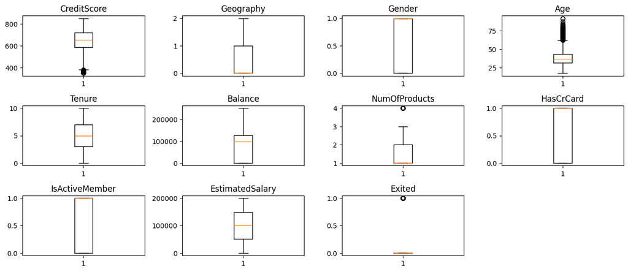

```python
# Outlier detection using boxplots
numeric_columns = data.select_dtypes(include=np.number).columns.tolist()

plt.figure(figsize=(13, 11))

for i, variable in enumerate(numeric_columns):
    plt.subplot(6, 4, i+1)
    plt.boxplot(data[variable], whis=1.5)
    plt.tight_layout()
    plt.title(variable)

plt.show()
```

- Outliers are present in the **CreditScore**, **Age**, and **NumofProducts** columns.
- These outliers will not be treated, as they appear to be valid data points that can provide valuable insights for the model.

```python
# Take another copy of the dataset
df = data.copy()
```

```python
df.dtypes
```

|  | 0 |
| --- | --- |
| CreditScore | int64 |
| Geography | int8 |
| Gender | int8 |
| Age | int64 |
| Tenure | int64 |
| Balance | float64 |
| NumOfProducts | int64 |
| HasCrCard | int64 |
| IsActiveMember | int64 |
| EstimatedSalary | float64 |
| Exited | int64 |

**dtype:** object

### Dummy Variable Creation

```python
# Separating the features and the target variable
X = df.drop(['Exited'], axis=1)   # independent variables
y = df['Exited']   # dependent variable
```

👉 Separating the features and target variable before dummy variable creation is necessary for avoiding data contamination.  
👉 Columns like **`Geography`** and **`Gender`** are already numerical (int8), so creating dummies would be redundant and could introduce unnecessary complexity.

### Train-Validation-Test Split

```python
# Splitting the data into training, validation and test sets (A 70/15/15 split)

# Step 1: Split the data into training (70%) and temporary (30%)
X_train, X_temp, y_train, y_temp = train_test_split(X, y, test_size=0.3, random_state=0, stratify=y)

# Step 2: Split the temporary set into validation (50% of temp -> 15% of total) and test (50% of temp -> 15% of total)
X_val, X_test, y_val, y_test = train_test_split(X_temp, y_temp, test_size=0.5, random_state=0, stratify=y_temp)

X_train.shape, X_val.shape, X_test.shape   # Print the shapes
```

```
((7000, 10), (1500, 10), (1500, 10))
```

- We have 7,000 observations in the **train set**, 1,500 observations in the **validation set**, and 1,500 observations in the **test set**.
- This is a 70% train, 15% validation, and 15% test distribution.

### Data Scaling

```python
# Check 10 random rows from the train dataset
X_train.sample(n=10, random_state=1)
```

|  | CreditScore | Geography | Gender | Age | Tenure | Balance | NumOfProducts | HasCrCard | IsActiveMember | EstimatedSalary |
| --- | --- | --- | --- | --- | --- | --- | --- | --- | --- | --- |
| 5364 | 812 | 1 | 1 | 33 | 2 | 127154.14 | 2 | 0 | 1 | 105383.49 |
| 6002 | 701 | 0 | 0 | 41 | 2 | 0.00 | 1 | 1 | 0 | 47856.78 |
| 5905 | 511 | 0 | 0 | 30 | 5 | 0.00 | 2 | 1 | 0 | 143994.86 |
| 6262 | 513 | 0 | 1 | 44 | 1 | 63562.02 | 2 | 0 | 1 | 52629.73 |
| 6036 | 674 | 0 | 0 | 27 | 4 | 79144.34 | 1 | 0 | 1 | 50743.83 |
| 3066 | 503 | 0 | 0 | 28 | 5 | 0.00 | 2 | 1 | 0 | 125918.17 |
| 3136 | 607 | 0 | 1 | 44 | 0 | 0.00 | 2 | 1 | 1 | 81140.09 |
| 2169 | 773 | 1 | 1 | 43 | 8 | 81844.91 | 2 | 1 | 1 | 35908.46 |
| 2005 | 785 | 1 | 0 | 32 | 3 | 124493.03 | 2 | 0 | 1 | 52583.79 |
| 1524 | 796 | 0 | 1 | 51 | 6 | 0.00 | 2 | 0 | 1 | 194733.28 |

- Before building our neural network, we need to use **scaling techniques** to ensure that all features are on similar scales, which helps the model converge faster and perform better.
- **Continuous Variables**: **`CreditScore`**, **`Age`**, **`Tenure`**, **`Balance`**, and **`EstimatedSalary`** vary widely in range and should be scaled.
- **Categorical Variables**: **`Geography`**, **`Gender`**, **`HasCrCard`**, **`IsActiveMember`** and **`NumOfProducts`** are already integer-encoded, and additional scaling is not needed.

#### Standardizing the continuous variables

- Typically, **StandardScaler** is used with neural networks to standardize the input features, which ensures better and faster training.
- Standardization ensures that the data follows a standard normal distribution (approximately), which is particularly useful for algorithms sensitive to feature scaling like neural networks.

```python
# Define the columns to scale
cont_columns = ["CreditScore", "Age", "Tenure", "Balance", "EstimatedSalary"]

# Initialize the StandardScaler
scaler = StandardScaler()

# Fit the scaler to the selected columns in the x_train data
scaler.fit(X_train[cont_columns])
```

```
StandardScaler()
```

- Once the scaler object fits on the data using the **`fit()`** method, it stores the parameters (mean and standard deviation) for normalization based on the training data.
- We then use these parameters to normalize the validation and test data.

```python
# Transform selected columns in X_train, X_val, and X_test using the fitted scaler
X_train[cont_columns] = scaler.transform(X_train[cont_columns])
X_val[cont_columns] = scaler.transform(X_val[cont_columns])
X_test[cont_columns] = scaler.transform(X_test[cont_columns])
```

```python
# Check 10 random rows from the train dataset after the transform
X_train.sample(n=10, random_state=1)
```

|  | CreditScore | Geography | Gender | Age | Tenure | Balance | NumOfProducts | HasCrCard | IsActiveMember | EstimatedSalary |
| --- | --- | --- | --- | --- | --- | --- | --- | --- | --- | --- |
| 5364 | 1.68 | 1 | 1 | -0.57 | -1.04 | 0.82 | 2 | 0 | 1 | 0.09 |
| 6002 | 0.53 | 0 | 0 | 0.20 | -1.04 | -1.23 | 1 | 1 | 0 | -0.91 |
| 5905 | -1.44 | 0 | 0 | -0.85 | 0.00 | -1.23 | 2 | 1 | 0 | 0.77 |
| 6262 | -1.42 | 0 | 1 | 0.49 | -1.38 | -0.21 | 2 | 0 | 1 | -0.82 |
| 6036 | 0.25 | 0 | 0 | -1.14 | -0.34 | 0.04 | 1 | 0 | 1 | -0.86 |
| 3066 | -1.52 | 0 | 0 | -1.05 | 0.00 | -1.23 | 2 | 1 | 0 | 0.45 |
| 3136 | -0.44 | 0 | 1 | 0.49 | -1.73 | -1.23 | 2 | 1 | 1 | -0.33 |
| 2169 | 1.28 | 1 | 1 | 0.39 | 1.04 | 0.09 | 2 | 1 | 1 | -1.11 |
| 2005 | 1.40 | 1 | 0 | -0.66 | -0.69 | 0.77 | 2 | 0 | 1 | -0.82 |
| 1524 | 1.52 | 0 | 1 | 1.16 | 0.35 | -1.23 | 2 | 0 | 1 | 1.65 |

```python
# Check 10 random rows from the validation dataset after the transform
X_val.sample(n=10, random_state=1)
```

|  | CreditScore | Geography | Gender | Age | Tenure | Balance | NumOfProducts | HasCrCard | IsActiveMember | EstimatedSalary |
| --- | --- | --- | --- | --- | --- | --- | --- | --- | --- | --- |
| 4709 | -0.99 | 0 | 1 | -0.76 | -1.38 | -1.23 | 2 | 0 | 1 | 1.61 |
| 4883 | -0.37 | 1 | 1 | 0.39 | 1.04 | 1.03 | 1 | 1 | 1 | 1.16 |
| 5858 | -0.83 | 0 | 0 | -0.85 | 1.74 | 1.60 | 1 | 1 | 0 | -0.05 |
| 886 | 0.93 | 2 | 1 | -0.09 | -1.73 | 0.84 | 1 | 1 | 0 | -1.52 |
| 5586 | 1.72 | 1 | 0 | -1.33 | -1.04 | 1.19 | 2 | 1 | 1 | -1.12 |
| 4888 | -2.20 | 0 | 1 | 0.96 | 1.39 | 0.57 | 2 | 0 | 1 | 1.16 |
| 721 | -1.98 | 2 | 0 | 0.29 | 0.35 | 0.86 | 2 | 1 | 1 | 1.35 |
| 5368 | -1.16 | 0 | 0 | 2.21 | -0.69 | -0.02 | 1 | 0 | 0 | -1.43 |
| 8820 | 0.02 | 1 | 1 | -0.28 | 1.39 | 1.20 | 1 | 0 | 0 | -0.48 |
| 9657 | -0.45 | 0 | 1 | -0.66 | 0.00 | 0.11 | 1 | 1 | 1 | 0.29 |

👉 After standard scaling, the continuous numerical features are transformed to have **a mean of 0 and a standard deviation of 1**, ensuring all features are on a comparable scale and optimized for neural network training.

```python
# Check class balance for whole data, train, validation, and test sets
print("Target value ratio in y")
print(y.value_counts(1))
print("*" * 80)
print("Target value ratio in y_train")
print(y_train.value_counts(1))
print("*" * 80)
print("Target value ratio in y_val")
print(y_val.value_counts(1))
print("*" * 80)
print("Target value ratio in y_test")
print(y_test.value_counts(1))
print("*" * 80)
```

```
Target value ratio in y
Exited
0   0.80
1   0.20
Name: proportion, dtype: float64
Target value ratio in y_train
Exited
0   0.80
1   0.20
Name: proportion, dtype: float64
Target value ratio in y_val
Exited
0   0.80
1   0.20
Name: proportion, dtype: float64
Target value ratio in y_test
Exited
0   0.80
1   0.20
Name: proportion, dtype: float64
```

- The same proportion of each class in the training, validation, and test sets (80% and 20%)

## Model Building

### Model Evaluation Criterion

**The nature of predictions will be made by this classification model can be translated as follows**:

- **True positives (TP)** are customers correctly predicted by the model to leave the bank.
- **False negatives (FN)** are customers who actually leave but are not predicted by the model to leave.
- **False positives (FP)** are customers incorrectly predicted to leave the bank but who actually stay.

**Model can make wrong predictions as:**

1. Predicting a customer is exiting and the customer is not exiting
2. Predicting a customer is not exiting and customer is exiting

**Which case is more important?**

- Predicting that a customer will not churn when they actually do can lead to significant losses for banks. This misclassification prevents the bank from taking proactive measures to retain these high-risk customers.

**Which metric to optimize?**

- The bank’s primary goal is to prevent customers from leaving by identifying those likely to cancel their services.
- In this case, the best evaluation metric would be **Recall**.
- High Recall (**minimizing False Negatives**) means the model can identify as many at-risk customers as possible. Failing to identify these customers (FN) means the bank cannot take proactive steps to retain them, which could result in significant revenue loss.
- While **Precision** (minimizing False Positives, where customers are wrongly flagged as at-risk) is important, the focus is more on **Recall** to ensure the bank does not miss potential churners.
- Therefore, **Recall** is the most critical metric for this task, although **F1 Score** could be considered if a balance between Precision and Recall is required. However, in this case, **Recall** remains the priority.

### Unity Functions

- The following function visualizes the training and validation loss or the chosen metric (such as Recall) over epochs by plotting them on a graph:

```python
def plot(history, name):
    """
    Function to plot loss & chosen metric

    history: an object which stores the metrics and losses.
    name: can be one of Loss or the metric
    """
    fig, ax = plt.subplots() #Creating a subplot with figure and axes
    plt.plot(history.history[name]) #Plotting the train metric or train loss
    plt.plot(history.history['val_'+name]) #Plotting the validation metric or validation loss

    plt.title('Model ' + name.capitalize()) #Defining the title of the plot
    plt.ylabel(name.capitalize()) #Capitalizing the first letter
    plt.xlabel('Epoch') #Defining the label for the X-axis
    fig.legend(['Train', 'Validation'], loc="upper right") #Defining the legend, loc controls the position of the legend
```

- We'll create a dataframe to store the results from all the models we build:

```python
# Defining the columns of the dataframe which are nothing but the hyper parameters and the metrics
columns = ["Hidden Layer Count","Neuron Count","Activation Function","Batch Size","Epoch Count","Optimizer","Learning Rate","Class Balancer","Regularization","Train Loss","Validation Loss","Train Recall","Validation Recall","Time in secs"]

# Creating a pandas dataframe
results = pd.DataFrame(columns=columns)
```

### Calculating Class Weight

- As we have are dealing with an **imbalance in class distribution**, we will be using class weights to allow the model to give proportionally more importance to the minority class.

```python
# Calculate class weights for the imbalanced dataset
cw = (y_train.shape[0]) / (np.bincount(y_train) * 2)  # Divide by 2 to normalize the weights

# Create a dictionary mapping class indices (0 and 1) to their respective class weights
cw_dict = {i: weight for i, weight in enumerate(cw)}

cw_dict  # Check the output
```

```
{0: 0.6279153211338356, 1: 2.4544179523141656}
```

### Neural Network with SGD Optimizer

We will begin with a **baseline model** configured as follows:

- **Architecture**: 1 input layer, 2 hidden layers, and 1 output layer.
- **Activation Functions**:
  - Hidden layers use the **ReLU** activation function.
  - Output layer uses the **sigmoid** activation function for binary classification.
- **Optimizer**: Stochastic Gradient Descent (**SGD**) without momentum.
- **Weight Initialization**: Default initializer for Dense layers in Keras is Glorot Uniform (also known as **Xavier Uniform**).

```python
batch_size = 32  # Number of samples processed before the model is updated
epochs = 50  # The model will pass over the entire dataset 50 times during training
```

```python
# Clears the current Keras session, resetting all layers and models previously created, freeing up memory and resources.
tf.keras.backend.clear_session()
```

```python
# Initializing the neural network
model_0 = Sequential()
model_0.add(Dense(64, activation="relu", input_dim=X_train.shape[1]))  # First hidden layer
model_0.add(Dense(32, activation="relu"))  # Second hidden layer
model_0.add(Dense(1, activation="sigmoid"))  # Output layer for binary classification
```

```python
model_0.summary()
```

```
Model: "sequential"
```

```
┏━━━━━━━━━━━━━━━━━━━━━━━━━━━━━━━━━━━━━━┳━━━━━━━━━━━━━━━━━━━━━━━━━━━━━┳━━━━━━━━━━━━━━━━━┓
┃ Layer (type)                         ┃ Output Shape                ┃         Param # ┃
┡━━━━━━━━━━━━━━━━━━━━━━━━━━━━━━━━━━━━━━╇━━━━━━━━━━━━━━━━━━━━━━━━━━━━━╇━━━━━━━━━━━━━━━━━┩
│ dense (Dense)                        │ (None, 64)                  │             704 │
├──────────────────────────────────────┼─────────────────────────────┼─────────────────┤
│ dense_1 (Dense)                      │ (None, 32)                  │           2,080 │
├──────────────────────────────────────┼─────────────────────────────┼─────────────────┤
│ dense_2 (Dense)                      │ (None, 1)                   │              33 │
└──────────────────────────────────────┴─────────────────────────────┴─────────────────┘
```

```
 Total params: 2,817 (11.00 KB)
```

```
 Trainable params: 2,817 (11.00 KB)
```

```
 Non-trainable params: 0 (0.00 B)
```

```python
optimizer = tf.keras.optimizers.SGD(learning_rate=0.01)    # defining SGD as the optimizer, no momentum defined
model_0.compile(loss='binary_crossentropy', optimizer=optimizer, metrics=[Recall()])
```

- By default, SGD optimizer in TensorFlow uses a learning rate of **0.01**. But this can be adjusted.
- We use **binary_crossentropy** as the loss function in binary classification tasks because it measures the difference between the predicted probabilities and the actual binary labels (0 or 1), helping the model learn to make accurate predictions.

```python
# Convert y_train to a NumPy Array
y_train = np.array(y_train).astype(int)
```

```python
# Record the start time for training
start = time.time()
# Train the model using the training data and evaluate it on the validation set
history = model_0.fit(X_train, y_train, validation_data=(X_val, y_val), batch_size=batch_size, epochs=epochs, class_weight=cw_dict)
# Record the end time for training
end = time.time()
```

```
219/219 ━━━━━━━━━━━━━━━━━━━━ 4s 11ms/step - loss: 0.6609 - recall: 0.4074 - val_loss: 0.6411 - val_recall: 0.6863
219/219 ━━━━━━━━━━━━━━━━━━━━ 0s 2ms/step - loss: 0.6187 - recall: 0.6870 - val_loss: 0.6135 - val_recall: 0.6993
219/219 ━━━━━━━━━━━━━━━━━━━━ 1s 2ms/step - loss: 0.5950 - recall: 0.6832 - val_loss: 0.6001 - val_recall: 0.6928
219/219 ━━━━━━━━━━━━━━━━━━━━ 1s 2ms/step - loss: 0.5832 - recall: 0.6870 - val_loss: 0.5921 - val_recall: 0.7092
219/219 ━━━━━━━━━━━━━━━━━━━━ 1s 2ms/step - loss: 0.5768 - recall: 0.6973 - val_loss: 0.5876 - val_recall: 0.7157
219/219 ━━━━━━━━━━━━━━━━━━━━ 1s 3ms/step - loss: 0.5723 - recall: 0.7105 - val_loss: 0.5838 - val_recall: 0.7255
219/219 ━━━━━━━━━━━━━━━━━━━━ 1s 3ms/step - loss: 0.5688 - recall: 0.7219 - val_loss: 0.5810 - val_recall: 0.7288
219/219 ━━━━━━━━━━━━━━━━━━━━ 1s 2ms/step - loss: 0.5658 - recall: 0.7181 - val_loss: 0.5791 - val_recall: 0.7255
219/219 ━━━━━━━━━━━━━━━━━━━━ 1s 2ms/step - loss: 0.5630 - recall: 0.7194 - val_loss: 0.5772 - val_recall: 0.7255
219/219 ━━━━━━━━━━━━━━━━━━━━ 1s 2ms/step - loss: 0.5606 - recall: 0.7215 - val_loss: 0.5751 - val_recall: 0.7320
219/219 ━━━━━━━━━━━━━━━━━━━━ 0s 2ms/step - loss: 0.5583 - recall: 0.7211 - val_loss: 0.5735 - val_recall: 0.7353
219/219 ━━━━━━━━━━━━━━━━━━━━ 1s 2ms/step - loss: 0.5560 - recall: 0.7245 - val_loss: 0.5713 - val_recall: 0.7353
219/219 ━━━━━━━━━━━━━━━━━━━━ 1s 2ms/step - loss: 0.5537 - recall: 0.7260 - val_loss: 0.5692 - val_recall: 0.7353
219/219 ━━━━━━━━━━━━━━━━━━━━ 1s 2ms/step - loss: 0.5514 - recall: 0.7300 - val_loss: 0.5674 - val_recall: 0.7386
219/219 ━━━━━━━━━━━━━━━━━━━━ 1s 2ms/step - loss: 0.5492 - recall: 0.7333 - val_loss: 0.5654 - val_recall: 0.7386
219/219 ━━━━━━━━━━━━━━━━━━━━ 0s 2ms/step - loss: 0.5469 - recall: 0.7332 - val_loss: 0.5631 - val_recall: 0.7418
219/219 ━━━━━━━━━━━━━━━━━━━━ 0s 2ms/step - loss: 0.5446 - recall: 0.7336 - val_loss: 0.5612 - val_recall: 0.7484
219/219 ━━━━━━━━━━━━━━━━━━━━ 0s 2ms/step - loss: 0.5423 - recall: 0.7344 - val_loss: 0.5589 - val_recall: 0.7516
219/219 ━━━━━━━━━━━━━━━━━━━━ 0s 2ms/step - loss: 0.5400 - recall: 0.7377 - val_loss: 0.5565 - val_recall: 0.7549
219/219 ━━━━━━━━━━━━━━━━━━━━ 1s 2ms/step - loss: 0.5377 - recall: 0.7383 - val_loss: 0.5539 - val_recall: 0.7582
219/219 ━━━━━━━━━━━━━━━━━━━━ 1s 2ms/step - loss: 0.5353 - recall: 0.7431 - val_loss: 0.5515 - val_recall: 0.7614
219/219 ━━━━━━━━━━━━━━━━━━━━ 1s 2ms/step - loss: 0.5329 - recall: 0.7418 - val_loss: 0.5497 - val_recall: 0.7647
219/219 ━━━━━━━━━━━━━━━━━━━━ 1s 2ms/step - loss: 0.5304 - recall: 0.7429 - val_loss: 0.5478 - val_recall: 0.7582
219/219 ━━━━━━━━━━━━━━━━━━━━ 1s 2ms/step - loss: 0.5280 - recall: 0.7448 - val_loss: 0.5454 - val_recall: 0.7582
219/219 ━━━━━━━━━━━━━━━━━━━━ 1s 2ms/step - loss: 0.5255 - recall: 0.7444 - val_loss: 0.5431 - val_recall: 0.7549
219/219 ━━━━━━━━━━━━━━━━━━━━ 1s 3ms/step - loss: 0.5232 - recall: 0.7455 - val_loss: 0.5411 - val_recall: 0.7614
219/219 ━━━━━━━━━━━━━━━━━━━━ 1s 3ms/step - loss: 0.5208 - recall: 0.7498 - val_loss: 0.5385 - val_recall: 0.7582
219/219 ━━━━━━━━━━━━━━━━━━━━ 1s 2ms/step - loss: 0.5184 - recall: 0.7490 - val_loss: 0.5358 - val_recall: 0.7582
219/219 ━━━━━━━━━━━━━━━━━━━━ 0s 2ms/step - loss: 0.5160 - recall: 0.7498 - val_loss: 0.5327 - val_recall: 0.7582
219/219 ━━━━━━━━━━━━━━━━━━━━ 1s 2ms/step - loss: 0.5136 - recall: 0.7455 - val_loss: 0.5306 - val_recall: 0.7582
219/219 ━━━━━━━━━━━━━━━━━━━━ 0s 2ms/step - loss: 0.5112 - recall: 0.7469 - val_loss: 0.5292 - val_recall: 0.7582
219/219 ━━━━━━━━━━━━━━━━━━━━ 0s 2ms/step - loss: 0.5089 - recall: 0.7498 - val_loss: 0.5273 - val_recall: 0.7549
219/219 ━━━━━━━━━━━━━━━━━━━━ 1s 2ms/step - loss: 0.5067 - recall: 0.7502 - val_loss: 0.5259 - val_recall: 0.7549
219/219 ━━━━━━━━━━━━━━━━━━━━ 1s 2ms/step - loss: 0.5046 - recall: 0.7504 - val_loss: 0.5249 - val_recall: 0.7549
219/219 ━━━━━━━━━━━━━━━━━━━━ 1s 2ms/step - loss: 0.5026 - recall: 0.7507 - val_loss: 0.5233 - val_recall: 0.7549
219/219 ━━━━━━━━━━━━━━━━━━━━ 1s 2ms/step - loss: 0.5006 - recall: 0.7500 - val_loss: 0.5212 - val_recall: 0.7516
219/219 ━━━━━━━━━━━━━━━━━━━━ 1s 2ms/step - loss: 0.4986 - recall: 0.7527 - val_loss: 0.5195 - val_recall: 0.7549
219/219 ━━━━━━━━━━━━━━━━━━━━ 1s 2ms/step - loss: 0.4967 - recall: 0.7570 - val_loss: 0.5181 - val_recall: 0.7614
219/219 ━━━━━━━━━━━━━━━━━━━━ 1s 2ms/step - loss: 0.4948 - recall: 0.7599 - val_loss: 0.5162 - val_recall: 0.7647
219/219 ━━━━━━━━━━━━━━━━━━━━ 1s 2ms/step - loss: 0.4929 - recall: 0.7610 - val_loss: 0.5145 - val_recall: 0.7614
219/219 ━━━━━━━━━━━━━━━━━━━━ 1s 2ms/step - loss: 0.4911 - recall: 0.7590 - val_loss: 0.5125 - val_recall: 0.7582
219/219 ━━━━━━━━━━━━━━━━━━━━ 1s 2ms/step - loss: 0.4894 - recall: 0.7587 - val_loss: 0.5111 - val_recall: 0.7614
219/219 ━━━━━━━━━━━━━━━━━━━━ 1s 2ms/step - loss: 0.4876 - recall: 0.7585 - val_loss: 0.5087 - val_recall: 0.7614
219/219 ━━━━━━━━━━━━━━━━━━━━ 0s 2ms/step - loss: 0.4858 - recall: 0.7547 - val_loss: 0.5067 - val_recall: 0.7582
219/219 ━━━━━━━━━━━━━━━━━━━━ 0s 2ms/step - loss: 0.4841 - recall: 0.7536 - val_loss: 0.5055 - val_recall: 0.7614
219/219 ━━━━━━━━━━━━━━━━━━━━ 1s 3ms/step - loss: 0.4823 - recall: 0.7551 - val_loss: 0.5047 - val_recall: 0.7712
219/219 ━━━━━━━━━━━━━━━━━━━━ 1s 3ms/step - loss: 0.4806 - recall: 0.7599 - val_loss: 0.5028 - val_recall: 0.7680
219/219 ━━━━━━━━━━━━━━━━━━━━ 1s 2ms/step - loss: 0.4789 - recall: 0.7603 - val_loss: 0.5015 - val_recall: 0.7680
219/219 ━━━━━━━━━━━━━━━━━━━━ 0s 2ms/step - loss: 0.4772 - recall: 0.7607 - val_loss: 0.5006 - val_recall: 0.7680
219/219 ━━━━━━━━━━━━━━━━━━━━ 1s 2ms/step - loss: 0.4756 - recall: 0.7617 - val_loss: 0.4993 - val_recall: 0.7712
```

```python
print("Time taken in seconds",end-start)
```

```
Time taken in seconds 36.328224897384644
```

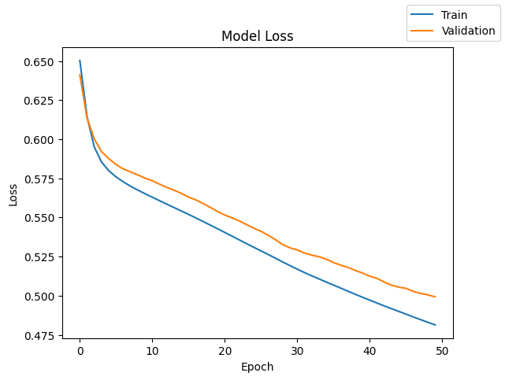

```python
plot(history, 'loss')
```

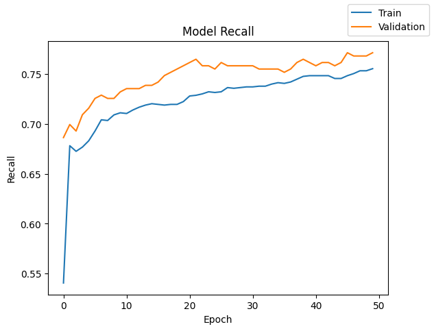

```python
plot(history, 'recall')
```

- The recall for both training and validation fluctuates during the initial epochs, indicating instability in learning.
- After epoch 10, recall steadily improves for both training and validation, with some minor oscillations.
- Validation recall closely follows training recall, suggesting minimal overfitting and good generalization.
- The gradual upward trend indicates that the model is progressively learning to identify positive instances better.

```python
results.loc[0] = [2,[64,32],["relu","relu"],batch_size,epochs,"sgd",[0.01],"class_weight","-",history.history["loss"][-1],history.history["val_loss"][-1],history.history["recall"][-1],history.history["val_recall"][-1],round(end-start,2)]
results
```

|  | Hidden Layer Count | Neuron Count | Activation Function | Batch Size | Epoch Count | Optimizer | Learning Rate | Class Balancer | Regularization | Train Loss | Validation Loss | Train Recall | Validation Recall | Time in secs |
| --- | --- | --- | --- | --- | --- | --- | --- | --- | --- | --- | --- | --- | --- | --- |
| 0 | 2 | [64, 32] | [relu, relu] | 32 | 50 | sgd | [0.01] | class_weight | - | 0.48 | 0.50 | 0.76 | 0.77 | 36.33 |

- The model performs reasonably well, but **recall fluctuates early on**, likely due to SGD's lack of momentum, which limits stability in updates.
- With a learning rate of 0.01, SGD may be taking smaller steps near flatter regions of the loss landscape, slowing initial improvement.
- **Adding momentum to SGD** or switching to **Adam** can improve convergence speed and reduce oscillations in recall.
- Batch size of 32 is appropriate, but **increasing it slightly** may stabilize gradient updates, improving metric consistency.

## Model Performance Improvement

Generally, to improve the performance of neural networks, we tune hyperparameters such as the number of layers, try different optimizers, add momentum, use regularization techniques like dropout, and balance the dataset.

### Neural Network with Adam Optimizer

We will use **Adam optimizer** this time configured as follows:

- **Architecture**: 1 input layer, 2 hidden layers, and 1 output layer.
- **Activation Functions**:
  - **ReLU** activation for the first hidden layer.
  - **Tanh** activation for the second hidden layer.
- **Optimizer**: Adam optimizer with **momentum** and an **adaptive learning rate** for efficient convergence.
- **Regularization**: L2 regularization helps reduce overfitting by penalizing large weights.

👉 **Adam** optimization is widely used in neural networks because it combines the benefits of momentum and adaptive learning rates, making it efficient, robust, and well-suited for a wide range of neural network architectures and datasets.

👉 The Adam optimizer does not use explicit **momentum** as in the traditional SGD with momentum. Instead, it incorporates momentum-like behavior through the use of exponentially decaying moving averages of past gradients and squared gradients.

```python
batch_size = 64  # Number of samples processed before the model is updated
epochs = 50  # The model will pass over the entire dataset 50 times during training
```

```python
# Clears the current Keras session, resetting all layers and models previously created, freeing up memory and resources.
tf.keras.backend.clear_session()
```

```python
# Initializing the neural network
model_1 = Sequential()
model_1.add(Dense(64, activation='relu', kernel_regularizer=regularizers.l2(0.01), input_dim=X_train.shape[1]))  # First layer ReLu with L2 regularization
model_1.add(Dense(32, activation='tanh', kernel_regularizer=regularizers.l2(0.01)))  # Second layer tanh with L2 regularization
model_1.add(Dense(1, activation="sigmoid"))  # Output layer for binary classification
```

```python
model_1.summary()
```

```
Model: "sequential"
```

```
┏━━━━━━━━━━━━━━━━━━━━━━━━━━━━━━━━━━━━━━┳━━━━━━━━━━━━━━━━━━━━━━━━━━━━━┳━━━━━━━━━━━━━━━━━┓
┃ Layer (type)                         ┃ Output Shape                ┃         Param # ┃
┡━━━━━━━━━━━━━━━━━━━━━━━━━━━━━━━━━━━━━━╇━━━━━━━━━━━━━━━━━━━━━━━━━━━━━╇━━━━━━━━━━━━━━━━━┩
│ dense (Dense)                        │ (None, 64)                  │             704 │
├──────────────────────────────────────┼─────────────────────────────┼─────────────────┤
│ dense_1 (Dense)                      │ (None, 32)                  │           2,080 │
├──────────────────────────────────────┼─────────────────────────────┼─────────────────┤
│ dense_2 (Dense)                      │ (None, 1)                   │              33 │
└──────────────────────────────────────┴─────────────────────────────┴─────────────────┘
```

```
 Total params: 2,817 (11.00 KB)
```

```
 Trainable params: 2,817 (11.00 KB)
```

```
 Non-trainable params: 0 (0.00 B)
```

```python
optimizer = tf.keras.optimizers.Adam(learning_rate=0.001)    # defining Adam as the optimizer
model_1.compile(loss='binary_crossentropy', optimizer=optimizer, metrics=[Recall()])
```

- By default, Adam uses a learning rate of **0.001**, but this can be adjusted.
- A **small learning rate** can help achieve more precise updates and prevent overshooting the optimal point, but it might make the training slower.

```python
# Record the start time for training
start = time.time()
# Train the model using the training data and evaluate it on the validation set
history = model_1.fit(X_train, y_train, validation_data=(X_val, y_val), batch_size=batch_size, epochs=epochs, class_weight=cw_dict)
# Record the end time for training
end = time.time()
```

```
110/110 ━━━━━━━━━━━━━━━━━━━━ 4s 19ms/step - loss: 1.1613 - recall: 0.5926 - val_loss: 0.9100 - val_recall: 0.6928
110/110 ━━━━━━━━━━━━━━━━━━━━ 2s 2ms/step - loss: 0.8547 - recall: 0.7023 - val_loss: 0.7630 - val_recall: 0.7157
110/110 ━━━━━━━━━━━━━━━━━━━━ 0s 2ms/step - loss: 0.7289 - recall: 0.7123 - val_loss: 0.6923 - val_recall: 0.7222
110/110 ━━━━━━━━━━━━━━━━━━━━ 0s 2ms/step - loss: 0.6694 - recall: 0.7158 - val_loss: 0.6539 - val_recall: 0.7157
110/110 ━━━━━━━━━━━━━━━━━━━━ 0s 2ms/step - loss: 0.6379 - recall: 0.7195 - val_loss: 0.6313 - val_recall: 0.7124
110/110 ━━━━━━━━━━━━━━━━━━━━ 0s 2ms/step - loss: 0.6190 - recall: 0.7229 - val_loss: 0.6185 - val_recall: 0.7222
110/110 ━━━━━━━━━━━━━━━━━━━━ 0s 2ms/step - loss: 0.6061 - recall: 0.7265 - val_loss: 0.6115 - val_recall: 0.7353
110/110 ━━━━━━━━━━━━━━━━━━━━ 0s 2ms/step - loss: 0.5961 - recall: 0.7379 - val_loss: 0.6085 - val_recall: 0.7484
110/110 ━━━━━━━━━━━━━━━━━━━━ 0s 3ms/step - loss: 0.5874 - recall: 0.7426 - val_loss: 0.6051 - val_recall: 0.7647
110/110 ━━━━━━━━━━━━━━━━━━━━ 0s 2ms/step - loss: 0.5792 - recall: 0.7466 - val_loss: 0.6020 - val_recall: 0.7745
110/110 ━━━━━━━━━━━━━━━━━━━━ 0s 2ms/step - loss: 0.5710 - recall: 0.7471 - val_loss: 0.5994 - val_recall: 0.7778
110/110 ━━━━━━━━━━━━━━━━━━━━ 0s 3ms/step - loss: 0.5627 - recall: 0.7542 - val_loss: 0.5937 - val_recall: 0.7974
110/110 ━━━━━━━━━━━━━━━━━━━━ 1s 3ms/step - loss: 0.5548 - recall: 0.7609 - val_loss: 0.5864 - val_recall: 0.7974
110/110 ━━━━━━━━━━━━━━━━━━━━ 1s 3ms/step - loss: 0.5477 - recall: 0.7602 - val_loss: 0.5783 - val_recall: 0.8007
110/110 ━━━━━━━━━━━━━━━━━━━━ 1s 3ms/step - loss: 0.5411 - recall: 0.7608 - val_loss: 0.5712 - val_recall: 0.8072
110/110 ━━━━━━━━━━━━━━━━━━━━ 0s 3ms/step - loss: 0.5357 - recall: 0.7635 - val_loss: 0.5642 - val_recall: 0.8072
110/110 ━━━━━━━━━━━━━━━━━━━━ 1s 3ms/step - loss: 0.5308 - recall: 0.7544 - val_loss: 0.5574 - val_recall: 0.7974
110/110 ━━━━━━━━━━━━━━━━━━━━ 1s 2ms/step - loss: 0.5267 - recall: 0.7583 - val_loss: 0.5524 - val_recall: 0.7876
110/110 ━━━━━━━━━━━━━━━━━━━━ 0s 3ms/step - loss: 0.5231 - recall: 0.7593 - val_loss: 0.5482 - val_recall: 0.7843
110/110 ━━━━━━━━━━━━━━━━━━━━ 0s 2ms/step - loss: 0.5198 - recall: 0.7603 - val_loss: 0.5442 - val_recall: 0.7876
110/110 ━━━━━━━━━━━━━━━━━━━━ 0s 2ms/step - loss: 0.5169 - recall: 0.7598 - val_loss: 0.5404 - val_recall: 0.7810
110/110 ━━━━━━━━━━━━━━━━━━━━ 0s 2ms/step - loss: 0.5143 - recall: 0.7597 - val_loss: 0.5365 - val_recall: 0.7778
110/110 ━━━━━━━━━━━━━━━━━━━━ 0s 2ms/step - loss: 0.5120 - recall: 0.7597 - val_loss: 0.5350 - val_recall: 0.7810
110/110 ━━━━━━━━━━━━━━━━━━━━ 0s 2ms/step - loss: 0.5097 - recall: 0.7608 - val_loss: 0.5315 - val_recall: 0.7810
110/110 ━━━━━━━━━━━━━━━━━━━━ 0s 2ms/step - loss: 0.5078 - recall: 0.7618 - val_loss: 0.5289 - val_recall: 0.7810
110/110 ━━━━━━━━━━━━━━━━━━━━ 0s 2ms/step - loss: 0.5061 - recall: 0.7636 - val_loss: 0.5254 - val_recall: 0.7843
110/110 ━━━━━━━━━━━━━━━━━━━━ 0s 2ms/step - loss: 0.5045 - recall: 0.7665 - val_loss: 0.5233 - val_recall: 0.7876
110/110 ━━━━━━━━━━━━━━━━━━━━ 0s 2ms/step - loss: 0.5029 - recall: 0.7630 - val_loss: 0.5205 - val_recall: 0.7810
110/110 ━━━━━━━━━━━━━━━━━━━━ 0s 2ms/step - loss: 0.5015 - recall: 0.7640 - val_loss: 0.5181 - val_recall: 0.7778
110/110 ━━━━━━━━━━━━━━━━━━━━ 0s 2ms/step - loss: 0.5000 - recall: 0.7645 - val_loss: 0.5166 - val_recall: 0.7745
110/110 ━━━━━━━━━━━━━━━━━━━━ 0s 2ms/step - loss: 0.4988 - recall: 0.7624 - val_loss: 0.5151 - val_recall: 0.7745
110/110 ━━━━━━━━━━━━━━━━━━━━ 0s 2ms/step - loss: 0.4975 - recall: 0.7620 - val_loss: 0.5131 - val_recall: 0.7745
110/110 ━━━━━━━━━━━━━━━━━━━━ 0s 2ms/step - loss: 0.4963 - recall: 0.7616 - val_loss: 0.5114 - val_recall: 0.7745
110/110 ━━━━━━━━━━━━━━━━━━━━ 0s 2ms/step - loss: 0.4952 - recall: 0.7576 - val_loss: 0.5104 - val_recall: 0.7745
110/110 ━━━━━━━━━━━━━━━━━━━━ 0s 2ms/step - loss: 0.4943 - recall: 0.7575 - val_loss: 0.5087 - val_recall: 0.7745
110/110 ━━━━━━━━━━━━━━━━━━━━ 0s 2ms/step - loss: 0.4932 - recall: 0.7591 - val_loss: 0.5073 - val_recall: 0.7745
110/110 ━━━━━━━━━━━━━━━━━━━━ 0s 2ms/step - loss: 0.4924 - recall: 0.7580 - val_loss: 0.5060 - val_recall: 0.7712
110/110 ━━━━━━━━━━━━━━━━━━━━ 0s 3ms/step - loss: 0.4915 - recall: 0.7575 - val_loss: 0.5048 - val_recall: 0.7614
110/110 ━━━━━━━━━━━━━━━━━━━━ 0s 2ms/step - loss: 0.4908 - recall: 0.7564 - val_loss: 0.5035 - val_recall: 0.7647
110/110 ━━━━━━━━━━━━━━━━━━━━ 0s 2ms/step - loss: 0.4900 - recall: 0.7548 - val_loss: 0.5035 - val_recall: 0.7614
110/110 ━━━━━━━━━━━━━━━━━━━━ 0s 2ms/step - loss: 0.4893 - recall: 0.7505 - val_loss: 0.5016 - val_recall: 0.7614
110/110 ━━━━━━━━━━━━━━━━━━━━ 0s 2ms/step - loss: 0.4886 - recall: 0.7438 - val_loss: 0.5011 - val_recall: 0.7549
110/110 ━━━━━━━━━━━━━━━━━━━━ 0s 2ms/step - loss: 0.4878 - recall: 0.7503 - val_loss: 0.5006 - val_recall: 0.7549
110/110 ━━━━━━━━━━━━━━━━━━━━ 0s 2ms/step - loss: 0.4871 - recall: 0.7435 - val_loss: 0.4991 - val_recall: 0.7582
110/110 ━━━━━━━━━━━━━━━━━━━━ 0s 2ms/step - loss: 0.4865 - recall: 0.7455 - val_loss: 0.4995 - val_recall: 0.7549
110/110 ━━━━━━━━━━━━━━━━━━━━ 0s 2ms/step - loss: 0.4858 - recall: 0.7459 - val_loss: 0.4984 - val_recall: 0.7549
110/110 ━━━━━━━━━━━━━━━━━━━━ 0s 2ms/step - loss: 0.4852 - recall: 0.7468 - val_loss: 0.4969 - val_recall: 0.7549
110/110 ━━━━━━━━━━━━━━━━━━━━ 0s 2ms/step - loss: 0.4847 - recall: 0.7421 - val_loss: 0.4960 - val_recall: 0.7549
110/110 ━━━━━━━━━━━━━━━━━━━━ 0s 2ms/step - loss: 0.4841 - recall: 0.7433 - val_loss: 0.4959 - val_recall: 0.7549
110/110 ━━━━━━━━━━━━━━━━━━━━ 0s 2ms/step - loss: 0.4835 - recall: 0.7462 - val_loss: 0.4957 - val_recall: 0.7516
```

```python
print("Time taken in seconds",end-start)
```

```
Time taken in seconds 22.123973846435547
```

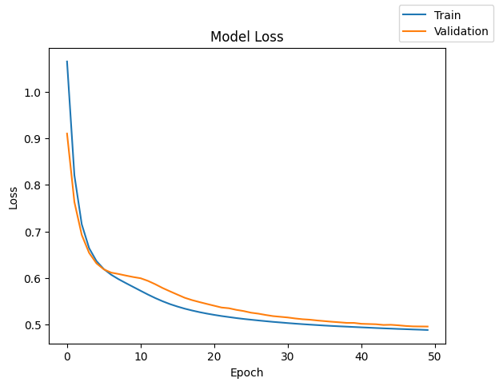

```python
plot(history, 'loss')
```

- **Improved Convergence**: Both training and validation losses show a steady decline, indicating that the model is learning effectively after the initial epochs.
- **Reduced Overfitting**: The gap between training and validation losses is small, suggesting that **L2 regularization** and the **`Adam` optimizer** help control overfitting.
- **Tanh Stability**: The use of **`tanh` in the second layer** does not cause noticeable instability, showing that it complements the model structure well for this dataset.
- **Optimization Efficiency**: The rapid decrease in loss during early epochs demonstrates that the **`Adam` optimizer**, combined with **batch size adjustments**, accelerates convergence compared to the previous configuration.

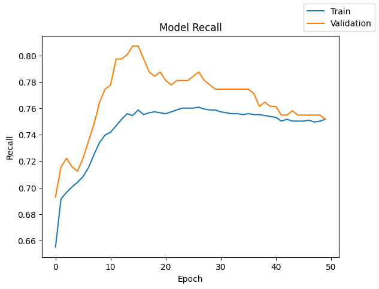

```python
plot(history, 'recall')
```

```python
results.loc[1] = [2,[64,32],["relu","tanh"],batch_size,epochs,"adam",[0.001],"class_weight","L2",history.history["loss"][-1],history.history["val_loss"][-1],history.history["recall"][-1],history.history["val_recall"][-1],round(end-start,2)]
results
```

|  | Hidden Layer Count | Neuron Count | Activation Function | Batch Size | Epoch Count | Optimizer | Learning Rate | Class Balancer | Regularization | Train Loss | Validation Loss | Train Recall | Validation Recall | Time in secs |
| --- | --- | --- | --- | --- | --- | --- | --- | --- | --- | --- | --- | --- | --- | --- |
| 0 | 2 | [64, 32] | [relu, relu] | 32 | 50 | sgd | [0.01] | class_weight | - | 0.48 | 0.50 | 0.76 | 0.77 | 36.33 |
| 1 | 2 | [64, 32] | [relu, tanh] | 64 | 50 | adam | [0.001] | class_weight | L2 | 0.49 | 0.50 | 0.75 | 0.75 | 22.12 |

### Neural Network with Adam Optimizer and Dropout

We will introduce **Dropout** for regularization, configured as follows:

- **Architecture**: 1 input layer, 2 hidden layers, and 1 output layer.
- **Activations**: **ReLU** for the first hidden layer and **tanh** for the second hidden layer.
- **Optimizer**: **Adam** optimizer with **dropout** applied (20%) in between hidden layers for regularization.
- **Regularization**: Combine **L2** regularization with **Dropout** to address overfitting.

👉 **Dropout** is a regularization technique that randomly deactivates a fraction of neurons during training to prevent overfitting, and it complements the Adam optimizer by helping maintain generalization while Adam efficiently adjusts weights.

```python
batch_size = 64  # Number of samples processed before the model is updated
epochs = 50  # The model will pass over the entire dataset 50 times during training
```

```python
# Clears the current Keras session, resetting all layers and models previously created, freeing up memory and resources.
tf.keras.backend.clear_session()
```

```python
# Initializing the neural network
model_2 = Sequential()

# First hidden layer with ReLU activation and L2 regularization
model_2.add(Dense(64, activation="relu", input_dim=X_train.shape[1], kernel_regularizer=regularizers.l2(0.001)))
model_2.add(Dropout(0.2))  # 20% Dropout to prevent overfitting

# Second hidden layer with tanh activation and L2 regularization
model_2.add(Dense(32, activation="tanh", kernel_regularizer=regularizers.l2(0.001)))
# Output layer for binary classification
model_2.add(Dense(1, activation="sigmoid"))
```

- **20%** of the neurons in the layer will be randomly "dropped out" on each forward pass.

```python
model_2.summary()
```

```
Model: "sequential"
```

```
┏━━━━━━━━━━━━━━━━━━━━━━━━━━━━━━━━━━━━━━┳━━━━━━━━━━━━━━━━━━━━━━━━━━━━━┳━━━━━━━━━━━━━━━━━┓
┃ Layer (type)                         ┃ Output Shape                ┃         Param # ┃
┡━━━━━━━━━━━━━━━━━━━━━━━━━━━━━━━━━━━━━━╇━━━━━━━━━━━━━━━━━━━━━━━━━━━━━╇━━━━━━━━━━━━━━━━━┩
│ dense (Dense)                        │ (None, 64)                  │             704 │
├──────────────────────────────────────┼─────────────────────────────┼─────────────────┤
│ dropout (Dropout)                    │ (None, 64)                  │               0 │
├──────────────────────────────────────┼─────────────────────────────┼─────────────────┤
│ dense_1 (Dense)                      │ (None, 32)                  │           2,080 │
├──────────────────────────────────────┼─────────────────────────────┼─────────────────┤
│ dense_2 (Dense)                      │ (None, 1)                   │              33 │
└──────────────────────────────────────┴─────────────────────────────┴─────────────────┘
```

```
 Total params: 2,817 (11.00 KB)
```

```
 Trainable params: 2,817 (11.00 KB)
```

```
 Non-trainable params: 0 (0.00 B)
```

```python
optimizer = tf.keras.optimizers.Adam(learning_rate=0.001)    # defining Adam as the optimizer
model_2.compile(loss='binary_crossentropy', optimizer=optimizer, metrics=[Recall()])
```

```python
# Record the start time for training
start = time.time()
# Train the model using the training data and evaluate it on the validation set
history = model_2.fit(X_train, y_train, validation_data=(X_val, y_val), batch_size=batch_size, epochs=epochs, class_weight=cw_dict)
# Record the end time for training
end = time.time()
```

```
110/110 ━━━━━━━━━━━━━━━━━━━━ 6s 27ms/step - loss: 0.7242 - recall: 0.5767 - val_loss: 0.6320 - val_recall: 0.6699
110/110 ━━━━━━━━━━━━━━━━━━━━ 1s 2ms/step - loss: 0.6398 - recall: 0.6775 - val_loss: 0.6214 - val_recall: 0.6928
110/110 ━━━━━━━━━━━━━━━━━━━━ 0s 2ms/step - loss: 0.6225 - recall: 0.6871 - val_loss: 0.6099 - val_recall: 0.6895
110/110 ━━━━━━━━━━━━━━━━━━━━ 0s 2ms/step - loss: 0.6086 - recall: 0.7012 - val_loss: 0.5984 - val_recall: 0.7059
110/110 ━━━━━━━━━━━━━━━━━━━━ 0s 2ms/step - loss: 0.5961 - recall: 0.7079 - val_loss: 0.5948 - val_recall: 0.7092
110/110 ━━━━━━━━━━━━━━━━━━━━ 0s 3ms/step - loss: 0.5889 - recall: 0.7150 - val_loss: 0.5901 - val_recall: 0.7222
110/110 ━━━━━━━━━━━━━━━━━━━━ 1s 3ms/step - loss: 0.5811 - recall: 0.7099 - val_loss: 0.5821 - val_recall: 0.7190
110/110 ━━━━━━━━━━━━━━━━━━━━ 1s 3ms/step - loss: 0.5733 - recall: 0.7199 - val_loss: 0.5715 - val_recall: 0.7190
110/110 ━━━━━━━━━━━━━━━━━━━━ 1s 3ms/step - loss: 0.5649 - recall: 0.7054 - val_loss: 0.5663 - val_recall: 0.7222
110/110 ━━━━━━━━━━━━━━━━━━━━ 1s 4ms/step - loss: 0.5606 - recall: 0.7183 - val_loss: 0.5632 - val_recall: 0.7353
110/110 ━━━━━━━━━━━━━━━━━━━━ 0s 2ms/step - loss: 0.5561 - recall: 0.7177 - val_loss: 0.5621 - val_recall: 0.7386
110/110 ━━━━━━━━━━━━━━━━━━━━ 0s 2ms/step - loss: 0.5500 - recall: 0.7183 - val_loss: 0.5641 - val_recall: 0.7386
110/110 ━━━━━━━━━━━━━━━━━━━━ 0s 2ms/step - loss: 0.5451 - recall: 0.7259 - val_loss: 0.5571 - val_recall: 0.7418
110/110 ━━━━━━━━━━━━━━━━━━━━ 0s 2ms/step - loss: 0.5405 - recall: 0.7308 - val_loss: 0.5511 - val_recall: 0.7451
110/110 ━━━━━━━━━━━━━━━━━━━━ 0s 2ms/step - loss: 0.5314 - recall: 0.7270 - val_loss: 0.5434 - val_recall: 0.7320
110/110 ━━━━━━━━━━━━━━━━━━━━ 0s 2ms/step - loss: 0.5303 - recall: 0.7387 - val_loss: 0.5452 - val_recall: 0.7484
110/110 ━━━━━━━━━━━━━━━━━━━━ 0s 2ms/step - loss: 0.5302 - recall: 0.7344 - val_loss: 0.5439 - val_recall: 0.7418
110/110 ━━━━━━━━━━━━━━━━━━━━ 0s 2ms/step - loss: 0.5300 - recall: 0.7381 - val_loss: 0.5380 - val_recall: 0.7484
110/110 ━━━━━━━━━━━━━━━━━━━━ 0s 2ms/step - loss: 0.5270 - recall: 0.7487 - val_loss: 0.5475 - val_recall: 0.7516
110/110 ━━━━━━━━━━━━━━━━━━━━ 0s 2ms/step - loss: 0.5246 - recall: 0.7348 - val_loss: 0.5378 - val_recall: 0.7451
110/110 ━━━━━━━━━━━━━━━━━━━━ 0s 2ms/step - loss: 0.5197 - recall: 0.7274 - val_loss: 0.5304 - val_recall: 0.7418
110/110 ━━━━━━━━━━━━━━━━━━━━ 0s 2ms/step - loss: 0.5201 - recall: 0.7379 - val_loss: 0.5275 - val_recall: 0.7484
110/110 ━━━━━━━━━━━━━━━━━━━━ 0s 2ms/step - loss: 0.5218 - recall: 0.7285 - val_loss: 0.5277 - val_recall: 0.7484
110/110 ━━━━━━━━━━━━━━━━━━━━ 0s 2ms/step - loss: 0.5119 - recall: 0.7569 - val_loss: 0.5196 - val_recall: 0.7484
110/110 ━━━━━━━━━━━━━━━━━━━━ 0s 2ms/step - loss: 0.5095 - recall: 0.7344 - val_loss: 0.5272 - val_recall: 0.7418
110/110 ━━━━━━━━━━━━━━━━━━━━ 1s 2ms/step - loss: 0.5048 - recall: 0.7586 - val_loss: 0.5191 - val_recall: 0.7484
110/110 ━━━━━━━━━━━━━━━━━━━━ 0s 2ms/step - loss: 0.5075 - recall: 0.7477 - val_loss: 0.5115 - val_recall: 0.7353
110/110 ━━━━━━━━━━━━━━━━━━━━ 0s 2ms/step - loss: 0.5086 - recall: 0.7375 - val_loss: 0.5076 - val_recall: 0.7451
110/110 ━━━━━━━━━━━━━━━━━━━━ 0s 2ms/step - loss: 0.4963 - recall: 0.7475 - val_loss: 0.5077 - val_recall: 0.7484
110/110 ━━━━━━━━━━━━━━━━━━━━ 0s 2ms/step - loss: 0.4932 - recall: 0.7666 - val_loss: 0.5084 - val_recall: 0.7549
110/110 ━━━━━━━━━━━━━━━━━━━━ 0s 3ms/step - loss: 0.5017 - recall: 0.7404 - val_loss: 0.5149 - val_recall: 0.7516
110/110 ━━━━━━━━━━━━━━━━━━━━ 1s 2ms/step - loss: 0.4888 - recall: 0.7533 - val_loss: 0.5108 - val_recall: 0.7647
110/110 ━━━━━━━━━━━━━━━━━━━━ 0s 2ms/step - loss: 0.4881 - recall: 0.7554 - val_loss: 0.4946 - val_recall: 0.7353
110/110 ━━━━━━━━━━━━━━━━━━━━ 0s 3ms/step - loss: 0.4899 - recall: 0.7632 - val_loss: 0.4889 - val_recall: 0.7353
110/110 ━━━━━━━━━━━━━━━━━━━━ 1s 2ms/step - loss: 0.4872 - recall: 0.7525 - val_loss: 0.4894 - val_recall: 0.7484
110/110 ━━━━━━━━━━━━━━━━━━━━ 0s 2ms/step - loss: 0.4846 - recall: 0.7622 - val_loss: 0.4943 - val_recall: 0.7516
110/110 ━━━━━━━━━━━━━━━━━━━━ 0s 2ms/step - loss: 0.4845 - recall: 0.7638 - val_loss: 0.4882 - val_recall: 0.7451
110/110 ━━━━━━━━━━━━━━━━━━━━ 0s 2ms/step - loss: 0.4858 - recall: 0.7499 - val_loss: 0.4974 - val_recall: 0.7516
110/110 ━━━━━━━━━━━━━━━━━━━━ 0s 2ms/step - loss: 0.4859 - recall: 0.7535 - val_loss: 0.4964 - val_recall: 0.7516
110/110 ━━━━━━━━━━━━━━━━━━━━ 0s 2ms/step - loss: 0.4783 - recall: 0.7627 - val_loss: 0.4855 - val_recall: 0.7386
110/110 ━━━━━━━━━━━━━━━━━━━━ 0s 2ms/step - loss: 0.4739 - recall: 0.7656 - val_loss: 0.4967 - val_recall: 0.7549
110/110 ━━━━━━━━━━━━━━━━━━━━ 0s 4ms/step - loss: 0.4726 - recall: 0.7815 - val_loss: 0.4894 - val_recall: 0.7549
110/110 ━━━━━━━━━━━━━━━━━━━━ 1s 3ms/step - loss: 0.4786 - recall: 0.7584 - val_loss: 0.4788 - val_recall: 0.7320
110/110 ━━━━━━━━━━━━━━━━━━━━ 1s 3ms/step - loss: 0.4792 - recall: 0.7568 - val_loss: 0.4911 - val_recall: 0.7418
110/110 ━━━━━━━━━━━━━━━━━━━━ 1s 3ms/step - loss: 0.4804 - recall: 0.7489 - val_loss: 0.4814 - val_recall: 0.7418
110/110 ━━━━━━━━━━━━━━━━━━━━ 0s 4ms/step - loss: 0.4734 - recall: 0.7670 - val_loss: 0.4799 - val_recall: 0.7418
110/110 ━━━━━━━━━━━━━━━━━━━━ 1s 3ms/step - loss: 0.4792 - recall: 0.7686 - val_loss: 0.4856 - val_recall: 0.7582
110/110 ━━━━━━━━━━━━━━━━━━━━ 1s 2ms/step - loss: 0.4791 - recall: 0.7584 - val_loss: 0.4828 - val_recall: 0.7418
110/110 ━━━━━━━━━━━━━━━━━━━━ 0s 2ms/step - loss: 0.4750 - recall: 0.7504 - val_loss: 0.4722 - val_recall: 0.7451
110/110 ━━━━━━━━━━━━━━━━━━━━ 0s 2ms/step - loss: 0.4700 - recall: 0.7677 - val_loss: 0.4881 - val_recall: 0.7549
```

```python
print("Time taken in seconds",end-start)
```

```
Time taken in seconds 25.31906795501709
```

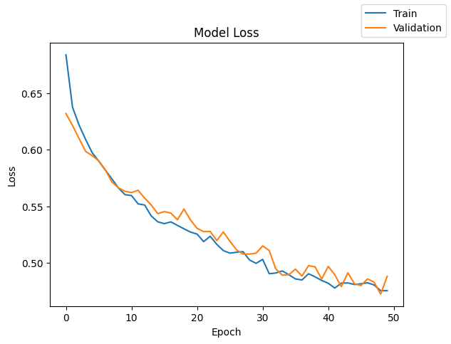

```python
plot(history, 'loss')
```

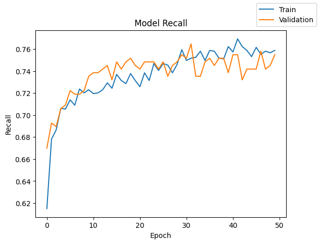

```python
plot(history, 'recall')
```

- **Initial Improvement**: There's a sharp increase in recall for the training data in the early epochs, indicating rapid learning in identifying the positive class.
- **Fluctuations**: Both training and validation recall exhibit fluctuations throughout the epochs. This could suggest **model sensitivity** to specific batches of data or the presence of **noise**.
- **Convergence**: Despite the fluctuations, the validation recall generally follows the training recall, indicating that the model is generalizing well across unseen data.

```python
results.loc[2] = [2,[64,32],["relu","tanh"],batch_size,epochs,"adam",[0.001],"class_weight","L2, dropout",history.history["loss"][-1],history.history["val_loss"][-1],history.history["recall"][-1],history.history["val_recall"][-1],round(end-start,2)]
results
```

|  | Hidden Layer Count | Neuron Count | Activation Function | Batch Size | Epoch Count | Optimizer | Learning Rate | Class Balancer | Regularization | Train Loss | Validation Loss | Train Recall | Validation Recall | Time in secs |
| --- | --- | --- | --- | --- | --- | --- | --- | --- | --- | --- | --- | --- | --- | --- |
| 0 | 2 | [64, 32] | [relu, relu] | 32 | 50 | sgd | [0.01] | class_weight | - | 0.48 | 0.50 | 0.76 | 0.77 | 36.33 |
| 1 | 2 | [64, 32] | [relu, tanh] | 64 | 50 | adam | [0.001] | class_weight | L2 | 0.49 | 0.50 | 0.75 | 0.75 | 22.12 |
| 2 | 2 | [64, 32] | [relu, tanh] | 64 | 50 | adam | [0.001] | class_weight | L2, dropout | 0.48 | 0.49 | 0.76 | 0.75 | 25.32 |

### Neural Network with Adam Optimizer and Dropout (Three layers)

We will modify the architecture with the following updates:

- **Architecture**: 1 input layer, 3 hidden layers, and 1 output layer.
- **Activations**: Add an additional **ReLU** activation for the hidden layers.
- **Learning Rate**: Decrease to **0.0005** for more stable convergence.
- **Regularization**: Include extra **BatchNormalization** and extra **Dropout** layers with L2 regularization.

```python
batch_size = 64  # Number of samples processed before the model is updated
epochs = 50  # The model will pass over the entire dataset 50 times during training
```

```python
# Clears the current Keras session, resetting all layers and models previously created, freeing up memory and resources.
tf.keras.backend.clear_session()
```

```python
# Initializing the neural network
model_3 = Sequential()
model_3.add(Dense(32, activation="relu", input_dim=X_train.shape[1], kernel_regularizer=regularizers.l2(0.0005)))  # First hidden layer ReLu with L2
model_3.add(BatchNormalization())  # Batch normalization 1
model_3.add(Dropout(0.2))  # Dropout to prevent overfitting

model_3.add(Dense(32, activation="relu", kernel_regularizer=regularizers.l2(0.0005)))  # Second hidden layer ReLu activation with L2
model_3.add(BatchNormalization())  # Batch normalization 2
model_3.add(Dropout(0.2))  # Dropout

model_3.add(Dense(16, activation="tanh", kernel_regularizer=regularizers.l2(0.0005)))  # Third hidden layer tanh activation with L2
model_3.add(BatchNormalization())  # Batch normalization 2
model_3.add(Dropout(0.3))  # Increased dropout for the last hidden layer
model_3.add(Dense(1, activation="sigmoid"))  # Output layer for binary classification
```

```python
model_3.summary()
```

```
Model: "sequential"
```

```
┏━━━━━━━━━━━━━━━━━━━━━━━━━━━━━━━━━━━━━━┳━━━━━━━━━━━━━━━━━━━━━━━━━━━━━┳━━━━━━━━━━━━━━━━━┓
┃ Layer (type)                         ┃ Output Shape                ┃         Param # ┃
┡━━━━━━━━━━━━━━━━━━━━━━━━━━━━━━━━━━━━━━╇━━━━━━━━━━━━━━━━━━━━━━━━━━━━━╇━━━━━━━━━━━━━━━━━┩
│ dense (Dense)                        │ (None, 32)                  │             352 │
├──────────────────────────────────────┼─────────────────────────────┼─────────────────┤
│ batch_normalization                  │ (None, 32)                  │             128 │
│ (BatchNormalization)                 │                             │                 │
├──────────────────────────────────────┼─────────────────────────────┼─────────────────┤
│ dropout (Dropout)                    │ (None, 32)                  │               0 │
├──────────────────────────────────────┼─────────────────────────────┼─────────────────┤
│ dense_1 (Dense)                      │ (None, 32)                  │           1,056 │
├──────────────────────────────────────┼─────────────────────────────┼─────────────────┤
│ batch_normalization_1                │ (None, 32)                  │             128 │
│ (BatchNormalization)                 │                             │                 │
├──────────────────────────────────────┼─────────────────────────────┼─────────────────┤
│ dropout_1 (Dropout)                  │ (None, 32)                  │               0 │
├──────────────────────────────────────┼─────────────────────────────┼─────────────────┤
│ dense_2 (Dense)                      │ (None, 16)                  │             528 │
├──────────────────────────────────────┼─────────────────────────────┼─────────────────┤
│ batch_normalization_2                │ (None, 16)                  │              64 │
│ (BatchNormalization)                 │                             │                 │
├──────────────────────────────────────┼─────────────────────────────┼─────────────────┤
│ dropout_2 (Dropout)                  │ (None, 16)                  │               0 │
├──────────────────────────────────────┼─────────────────────────────┼─────────────────┤
│ dense_3 (Dense)                      │ (None, 1)                   │              17 │
└──────────────────────────────────────┴─────────────────────────────┴─────────────────┘
```

```
 Total params: 2,273 (8.88 KB)
```

```
 Trainable params: 2,113 (8.25 KB)
```

```
 Non-trainable params: 160 (640.00 B)
```

```python
optimizer = tf.keras.optimizers.Adam(learning_rate=0.0005)    # defining Adam as the optimizer with lr of 0.0005
model_3.compile(loss='binary_crossentropy', optimizer=optimizer, metrics=[Recall()])
```

👉 Decreasing the learning rate stabilizes training and enables fine-tuning near the loss minimum but can slow convergence.

```python
# Record the start time for training
start = time.time()
# Train the model using the training data and evaluate it on the validation set
history = model_3.fit(X_train, y_train, validation_data=(X_val, y_val), batch_size=batch_size, epochs=epochs, class_weight=cw_dict)
# Record the end time for training
end = time.time()
```

```
110/110 ━━━━━━━━━━━━━━━━━━━━ 10s 40ms/step - loss: 0.8365 - recall: 0.5800 - val_loss: 0.6372 - val_recall: 0.5588
110/110 ━━━━━━━━━━━━━━━━━━━━ 2s 3ms/step - loss: 0.7255 - recall: 0.6339 - val_loss: 0.6393 - val_recall: 0.7222
110/110 ━━━━━━━━━━━━━━━━━━━━ 1s 3ms/step - loss: 0.6980 - recall: 0.6565 - val_loss: 0.6287 - val_recall: 0.6993
110/110 ━━━━━━━━━━━━━━━━━━━━ 1s 2ms/step - loss: 0.6783 - recall: 0.6879 - val_loss: 0.6256 - val_recall: 0.6961
110/110 ━━━━━━━━━━━━━━━━━━━━ 0s 3ms/step - loss: 0.6608 - recall: 0.6675 - val_loss: 0.6215 - val_recall: 0.7124
110/110 ━━━━━━━━━━━━━━━━━━━━ 0s 3ms/step - loss: 0.6535 - recall: 0.6702 - val_loss: 0.6204 - val_recall: 0.7124
110/110 ━━━━━━━━━━━━━━━━━━━━ 1s 3ms/step - loss: 0.6616 - recall: 0.6632 - val_loss: 0.6087 - val_recall: 0.7026
110/110 ━━━━━━━━━━━━━━━━━━━━ 0s 3ms/step - loss: 0.6310 - recall: 0.6825 - val_loss: 0.6039 - val_recall: 0.6961
110/110 ━━━━━━━━━━━━━━━━━━━━ 0s 3ms/step - loss: 0.6275 - recall: 0.7045 - val_loss: 0.6025 - val_recall: 0.7092
110/110 ━━━━━━━━━━━━━━━━━━━━ 0s 3ms/step - loss: 0.6290 - recall: 0.6868 - val_loss: 0.5981 - val_recall: 0.6895
110/110 ━━━━━━━━━━━━━━━━━━━━ 1s 3ms/step - loss: 0.6248 - recall: 0.6807 - val_loss: 0.5995 - val_recall: 0.6928
110/110 ━━━━━━━━━━━━━━━━━━━━ 0s 4ms/step - loss: 0.6193 - recall: 0.7148 - val_loss: 0.5957 - val_recall: 0.7059
110/110 ━━━━━━━━━━━━━━━━━━━━ 1s 4ms/step - loss: 0.6091 - recall: 0.7204 - val_loss: 0.5904 - val_recall: 0.7092
110/110 ━━━━━━━━━━━━━━━━━━━━ 0s 4ms/step - loss: 0.6089 - recall: 0.7264 - val_loss: 0.5884 - val_recall: 0.6961
110/110 ━━━━━━━━━━━━━━━━━━━━ 0s 4ms/step - loss: 0.6005 - recall: 0.7121 - val_loss: 0.5835 - val_recall: 0.6993
110/110 ━━━━━━━━━━━━━━━━━━━━ 0s 4ms/step - loss: 0.5977 - recall: 0.7249 - val_loss: 0.5791 - val_recall: 0.6993
110/110 ━━━━━━━━━━━━━━━━━━━━ 1s 4ms/step - loss: 0.6035 - recall: 0.7025 - val_loss: 0.5710 - val_recall: 0.6928
110/110 ━━━━━━━━━━━━━━━━━━━━ 1s 4ms/step - loss: 0.6023 - recall: 0.7252 - val_loss: 0.5683 - val_recall: 0.6928
110/110 ━━━━━━━━━━━━━━━━━━━━ 1s 3ms/step - loss: 0.5930 - recall: 0.7122 - val_loss: 0.5626 - val_recall: 0.6928
110/110 ━━━━━━━━━━━━━━━━━━━━ 0s 3ms/step - loss: 0.5816 - recall: 0.7253 - val_loss: 0.5586 - val_recall: 0.6993
110/110 ━━━━━━━━━━━━━━━━━━━━ 1s 3ms/step - loss: 0.5897 - recall: 0.7214 - val_loss: 0.5539 - val_recall: 0.7124
110/110 ━━━━━━━━━━━━━━━━━━━━ 0s 3ms/step - loss: 0.5743 - recall: 0.7373 - val_loss: 0.5453 - val_recall: 0.7124
110/110 ━━━━━━━━━━━━━━━━━━━━ 1s 3ms/step - loss: 0.5766 - recall: 0.7317 - val_loss: 0.5456 - val_recall: 0.7190
110/110 ━━━━━━━━━━━━━━━━━━━━ 1s 3ms/step - loss: 0.5733 - recall: 0.7164 - val_loss: 0.5437 - val_recall: 0.7353
110/110 ━━━━━━━━━━━━━━━━━━━━ 1s 3ms/step - loss: 0.5602 - recall: 0.7443 - val_loss: 0.5372 - val_recall: 0.7353
110/110 ━━━━━━━━━━━━━━━━━━━━ 0s 3ms/step - loss: 0.5540 - recall: 0.7469 - val_loss: 0.5297 - val_recall: 0.7353
110/110 ━━━━━━━━━━━━━━━━━━━━ 0s 3ms/step - loss: 0.5603 - recall: 0.7307 - val_loss: 0.5209 - val_recall: 0.7353
110/110 ━━━━━━━━━━━━━━━━━━━━ 0s 3ms/step - loss: 0.5555 - recall: 0.7479 - val_loss: 0.5114 - val_recall: 0.7255
110/110 ━━━━━━━━━━━━━━━━━━━━ 1s 3ms/step - loss: 0.5436 - recall: 0.7556 - val_loss: 0.5074 - val_recall: 0.7255
110/110 ━━━━━━━━━━━━━━━━━━━━ 0s 3ms/step - loss: 0.5473 - recall: 0.7328 - val_loss: 0.5092 - val_recall: 0.7353
110/110 ━━━━━━━━━━━━━━━━━━━━ 0s 3ms/step - loss: 0.5423 - recall: 0.7410 - val_loss: 0.5092 - val_recall: 0.7484
110/110 ━━━━━━━━━━━━━━━━━━━━ 0s 3ms/step - loss: 0.5379 - recall: 0.7482 - val_loss: 0.4993 - val_recall: 0.7320
110/110 ━━━━━━━━━━━━━━━━━━━━ 1s 3ms/step - loss: 0.5279 - recall: 0.7495 - val_loss: 0.4975 - val_recall: 0.7484
110/110 ━━━━━━━━━━━━━━━━━━━━ 0s 3ms/step - loss: 0.5351 - recall: 0.7537 - val_loss: 0.4934 - val_recall: 0.7418
110/110 ━━━━━━━━━━━━━━━━━━━━ 1s 3ms/step - loss: 0.5379 - recall: 0.7458 - val_loss: 0.4895 - val_recall: 0.7288
110/110 ━━━━━━━━━━━━━━━━━━━━ 1s 3ms/step - loss: 0.5374 - recall: 0.7297 - val_loss: 0.4927 - val_recall: 0.7353
110/110 ━━━━━━━━━━━━━━━━━━━━ 0s 3ms/step - loss: 0.5364 - recall: 0.7275 - val_loss: 0.4916 - val_recall: 0.7418
110/110 ━━━━━━━━━━━━━━━━━━━━ 0s 3ms/step - loss: 0.5349 - recall: 0.7307 - val_loss: 0.4918 - val_recall: 0.7451
110/110 ━━━━━━━━━━━━━━━━━━━━ 0s 3ms/step - loss: 0.5280 - recall: 0.7545 - val_loss: 0.4818 - val_recall: 0.7255
110/110 ━━━━━━━━━━━━━━━━━━━━ 0s 3ms/step - loss: 0.5199 - recall: 0.7502 - val_loss: 0.4829 - val_recall: 0.7418
110/110 ━━━━━━━━━━━━━━━━━━━━ 0s 3ms/step - loss: 0.5177 - recall: 0.7575 - val_loss: 0.4854 - val_recall: 0.7418
110/110 ━━━━━━━━━━━━━━━━━━━━ 1s 4ms/step - loss: 0.5208 - recall: 0.7534 - val_loss: 0.4808 - val_recall: 0.7190
110/110 ━━━━━━━━━━━━━━━━━━━━ 1s 4ms/step - loss: 0.5166 - recall: 0.7456 - val_loss: 0.4814 - val_recall: 0.7320
110/110 ━━━━━━━━━━━━━━━━━━━━ 1s 4ms/step - loss: 0.5205 - recall: 0.7394 - val_loss: 0.4831 - val_recall: 0.7353
110/110 ━━━━━━━━━━━━━━━━━━━━ 1s 4ms/step - loss: 0.5044 - recall: 0.7785 - val_loss: 0.4777 - val_recall: 0.7288
110/110 ━━━━━━━━━━━━━━━━━━━━ 0s 4ms/step - loss: 0.5135 - recall: 0.7447 - val_loss: 0.4839 - val_recall: 0.7418
110/110 ━━━━━━━━━━━━━━━━━━━━ 0s 3ms/step - loss: 0.5019 - recall: 0.7674 - val_loss: 0.4764 - val_recall: 0.7255
110/110 ━━━━━━━━━━━━━━━━━━━━ 0s 2ms/step - loss: 0.5070 - recall: 0.7488 - val_loss: 0.4743 - val_recall: 0.7222
110/110 ━━━━━━━━━━━━━━━━━━━━ 0s 3ms/step - loss: 0.5143 - recall: 0.7446 - val_loss: 0.4729 - val_recall: 0.7157
110/110 ━━━━━━━━━━━━━━━━━━━━ 1s 3ms/step - loss: 0.5000 - recall: 0.7504 - val_loss: 0.4747 - val_recall: 0.7190
```